# Blood Gas Data from NEAq Research

# 1) What is the dataset?

- Blood samples were collected in 2013 from 10 Turtles (Red-eared sliders), and 10 stingrays (Cownose rays)
- Turtles were selected from Rainforest Reptile Shows in Beverly, MA
- Rays were opportunistically selected from the shark and ray touch tank at the NEAq during routine spine clipping
- blood was analyzed for pH, pCO2, pO2, and lactate values using an iStat analyzer
- each sample was analyzed immediately (T0) and at 5, 10, 15, 45, and 90 minutes following

```r
head(complete_sliders)
##   Turtle Time  Lac      pH     PCO2       PO2
## 1      1    0 3.29 8.05244 302.0809  476.7898
## 2      1    5 3.20 8.06944 300.6355  491.6894
## 3      1   10 3.17 8.05644 307.8623  506.5891
## 4      1   15 3.30 8.07444 296.2994  566.1878
## 5      1   45 3.27 7.97344 352.6686  849.2818
## 6      1   90 3.31 7.95644 343.9964 1087.6767
head(complete_rays)
##    Ray Time  Lac       pH   PCO2    PO2 Syringe
## 1 7813    0 1.15 7.579830 2.5915 -1.449       P
## 2 7813    0 1.16 7.576650 2.5569     NA       G
## 3 7813    5 1.18 7.583805 2.5742  1.983       P
## 4 7813    5 1.10 7.576650 2.5742 -1.449       G
## 5 7813   10 1.11 7.583010 2.6088  1.411       P
## 6 7813   10 1.13 7.571880 2.6261 -1.449       G
```

# 2) What is your question?

- Are there changes in blood acid-base parameters over time?
- Do the blood acid-base parameters different between different syringe types (glass vs plastic)?

*These values are typically measured to assess stress levels of fish, samples are taken on a boat and usually can’t be analyzed until they are brought back to a lab.*

# 3) One visualization that addresses the question

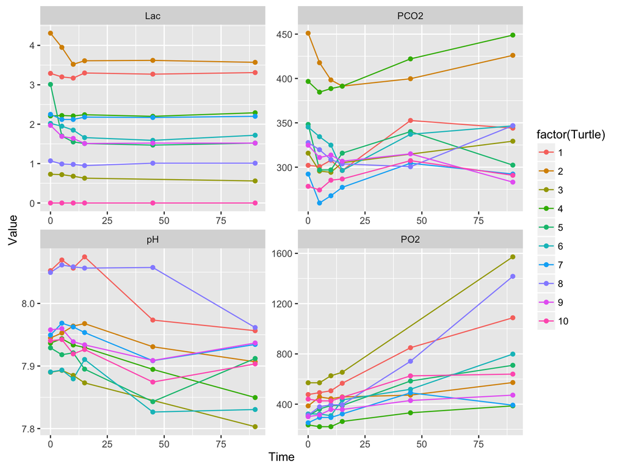

# 4) One analysis

- Null hypothesis: slope is equal to zero (no sig. change in lac value over time)
- Alt hypothesis: slope NOT equal to zero (lac value changes over time)

```r
Lac_mod <- lm(Lac ~ Time, data =  complete_sliders)
summary(Lac_mod)
##
## Call:
## lm(formula = Lac ~ Time, data = complete_sliders)
##
## Residuals:
##      Min       1Q   Median       3Q      Max
## -1.89205 -0.81881 -0.03911  0.40766  2.41795
##
## Coefficients:
##              Estimate Std. Error t value Pr(>|t|)
## (Intercept)  1.892046   0.190296   9.943 4.64e-14 ***
## Time        -0.001477   0.004561  -0.324    0.747
## ---
## Signif. codes:  0 '***' 0.001 '**' 0.01 '*' 0.05 '.' 0.1 ' ' 1
##
## Residual standard error: 1.108 on 57 degrees of freedom
## Multiple R-squared:  0.001837,   Adjusted R-squared:  -0.01567
## F-statistic: 0.1049 on 1 and 57 DF,  p-value: 0.7472
```

- Fail to reject the null hypothesis because of the high p-value for Time
- Lactate does not change significantly over time
- Time estimate value also supports the conclusion that the slope is zero

# 5) Where I am going…

- t-test comparing glass and plastic syringes?

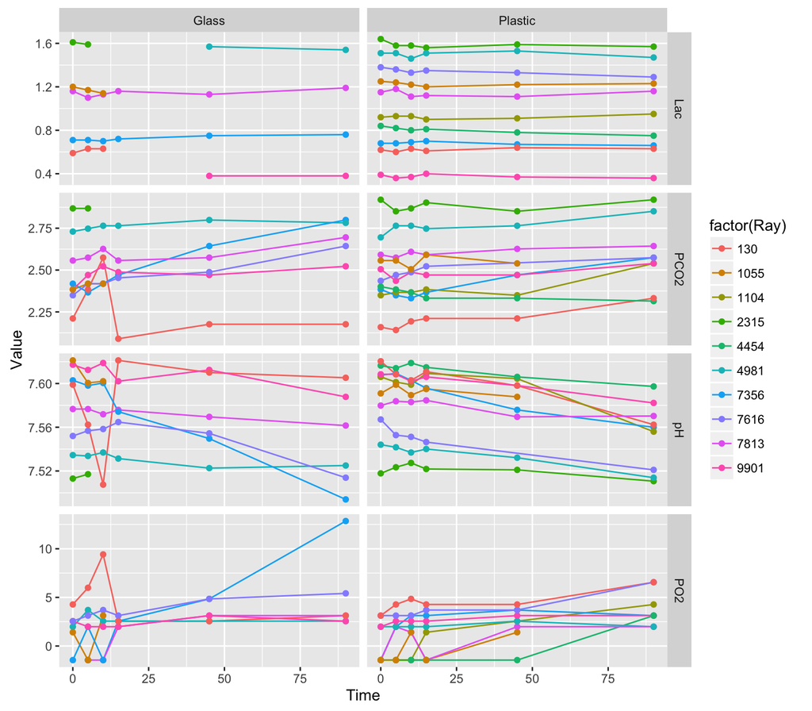

# Confused.

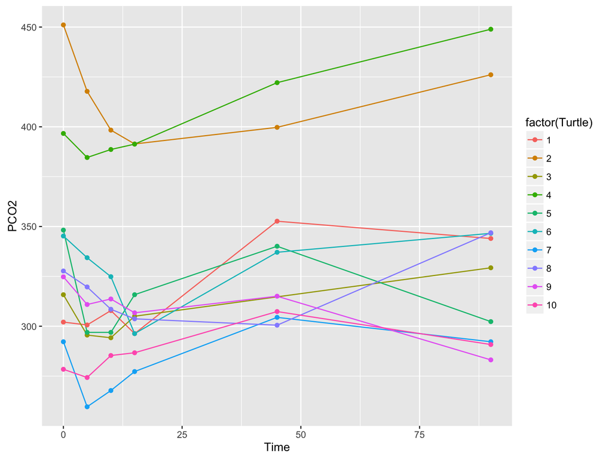

# Model summary

```
##
## Call:
## lm(formula = PCO2 ~ Time, data = complete_sliders)
##
## Residuals:
##    Min     1Q Median     3Q    Max
## -64.88 -30.31 -13.60  14.79 127.64
##
## Coefficients:
##             Estimate Std. Error t value Pr(>|t|)
## (Intercept) 323.4326     8.0364   40.25   <2e-16 ***
## Time          0.2119     0.1926    1.10    0.276
## ---
## Signif. codes:  0 '***' 0.001 '**' 0.01 '*' 0.05 '.' 0.1 ' ' 1
##
## Residual standard error: 46.81 on 57 degrees of freedom
## Multiple R-squared:  0.0208, Adjusted R-squared:  0.003625
## F-statistic: 1.211 on 1 and 57 DF,  p-value: 0.2758
```

# Assumptions

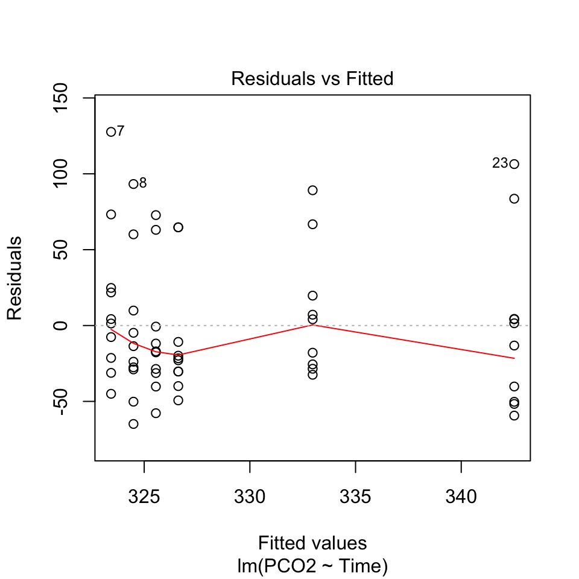

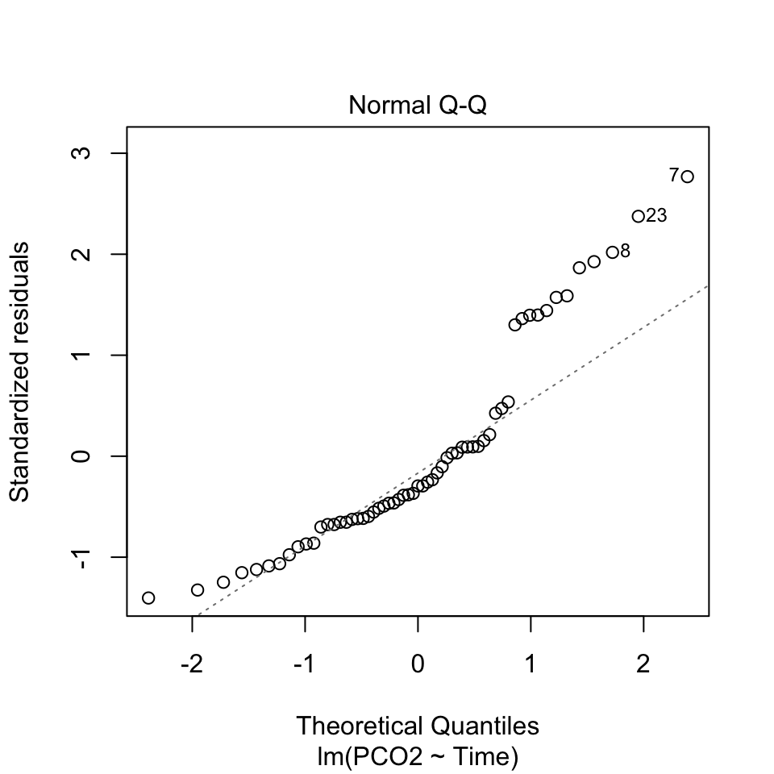